# Data handling in R with the tidy package

# 1. dplyr

`dplyr` is a library from the tidyverse which allows us to use a different, more expressive syntax when working with datasets. The general idea is, that you build a chain of transformations on your data instead of performing each step one-by-one. It also introduces a new type of dataframe which is called a `tibble`.

```r
# we first load the dataset and the library
library(dplyr)
df_iris <- read.csv("datasets/iris.csv")
#Summarize
summary(df_iris)
```

```
##   sepal_length    sepal_width     petal_length    petal_width
##  Min.   :4.300   Min.   :2.000   Min.   :1.000   Min.   :0.100
##  1st Qu.:5.100   1st Qu.:2.800   1st Qu.:1.600   1st Qu.:0.300
##  Median :5.800   Median :3.000   Median :4.350   Median :1.300
##  Mean   :5.843   Mean   :3.057   Mean   :3.758   Mean   :1.199
##  3rd Qu.:6.400   3rd Qu.:3.300   3rd Qu.:5.100   3rd Qu.:1.800
##  Max.   :7.900   Max.   :4.400   Max.   :6.900   Max.   :2.500
##    species
##  Length:150
##  Class :character
##  Mode  :character
##
##
##
```

# 2. exploring the data

Next, we will start to use `dplyr` to explore our data. The objectives are the same as in the native R notebook.

```r
#Select a column
df_iris %>% pull(sepal_length)
```

```
##  [1] 5.1 4.9 4.7 4.6 5.0 5.4 4.6 5.0 4.4 4.9 5.4 4.8 4.8 4.3 5.8 5.7 5.4 5.1 5.7
## [20] 5.1 5.4 5.1 4.6 5.1 4.8 5.0 5.0 5.2 5.2 4.7
##  [ reached getOption("max.print") -- omitted 120 entries ]
```

```r
#Select multiple columns
df_iris %>% select(sepal_length, sepal_width)
```

| sepal_length | sepal_width |
| --- | --- |
| 5.1 | 3.5 |
| 4.9 | 3.0 |
| 4.7 | 3.2 |
| 4.6 | 3.1 |
| 5.0 | 3.6 |
| 5.4 | 3.9 |
| 4.6 | 3.4 |
| 5.0 | 3.4 |
| 4.4 | 2.9 |
| 4.9 | 3.1 |

[output cut: 20 more lines]

```r
#Select multiple columns and only specific rows
df_iris %>%
  slice(1:10) %>%
  select(sepal_length, sepal_width)
```

| sepal_length | sepal_width |
| --- | --- |
| 5.1 | 3.5 |
| 4.9 | 3.0 |
| 4.7 | 3.2 |
| 4.6 | 3.1 |
| 5.0 | 3.6 |
| 5.4 | 3.9 |
| 4.6 | 3.4 |
| 5.0 | 3.4 |
| 4.4 | 2.9 |
| 4.9 | 3.1 |

```r
#Find indexes that match a condition
df_iris %>%
  mutate(sepal_length_gt_6 = sepal_length > 6.0) %>%
  pull(sepal_length_gt_6)
```

```
##  [1] FALSE FALSE FALSE FALSE FALSE FALSE FALSE FALSE FALSE FALSE FALSE FALSE
## [13] FALSE FALSE FALSE FALSE FALSE FALSE FALSE FALSE FALSE FALSE FALSE FALSE
## [25] FALSE FALSE FALSE FALSE FALSE FALSE
##  [ reached getOption("max.print") -- omitted 120 entries ]
```

```r
# Conditional selection
df_iris %>%
  filter(sepal_length > 6.0)
```

| sepal_length | sepal_width | petal_length | petal_width | species |
| --- | --- | --- | --- | --- |
| 7.0 | 3.2 | 4.7 | 1.4 | versicolor |
| 6.4 | 3.2 | 4.5 | 1.5 | versicolor |
| 6.9 | 3.1 | 4.9 | 1.5 | versicolor |
| 6.5 | 2.8 | 4.6 | 1.5 | versicolor |
| 6.3 | 3.3 | 4.7 | 1.6 | versicolor |
| 6.6 | 2.9 | 4.6 | 1.3 | versicolor |
| 6.1 | 2.9 | 4.7 | 1.4 | versicolor |
| 6.7 | 3.1 | 4.4 | 1.4 | versicolor |
| 6.2 | 2.2 | 4.5 | 1.5 | versicolor |
| 6.1 | 2.8 | 4.0 | 1.3 | versicolor |

[output cut: 20 more lines]

```r
# Multiple Conditions
df_iris %>%
  filter(sepal_length > 6.0, species == "versicolor")
```

| sepal_length | sepal_width | petal_length | petal_width | species |
| --- | --- | --- | --- | --- |
| 7.0 | 3.2 | 4.7 | 1.4 | versicolor |
| 6.4 | 3.2 | 4.5 | 1.5 | versicolor |
| 6.9 | 3.1 | 4.9 | 1.5 | versicolor |
| 6.5 | 2.8 | 4.6 | 1.5 | versicolor |
| 6.3 | 3.3 | 4.7 | 1.6 | versicolor |
| 6.6 | 2.9 | 4.6 | 1.3 | versicolor |
| 6.1 | 2.9 | 4.7 | 1.4 | versicolor |
| 6.7 | 3.1 | 4.4 | 1.4 | versicolor |
| 6.2 | 2.2 | 4.5 | 1.5 | versicolor |
| 6.1 | 2.8 | 4.0 | 1.3 | versicolor |

[output cut: 10 more lines]

```r
df_iris %>%
  filter(sepal_length > 6.0 | species == "versicolor")
```

| sepal_length | sepal_width | petal_length | petal_width | species |
| --- | --- | --- | --- | --- |
| 7.0 | 3.2 | 4.7 | 1.4 | versicolor |
| 6.4 | 3.2 | 4.5 | 1.5 | versicolor |
| 6.9 | 3.1 | 4.9 | 1.5 | versicolor |
| 5.5 | 2.3 | 4.0 | 1.3 | versicolor |
| 6.5 | 2.8 | 4.6 | 1.5 | versicolor |
| 5.7 | 2.8 | 4.5 | 1.3 | versicolor |
| 6.3 | 3.3 | 4.7 | 1.6 | versicolor |
| 4.9 | 2.4 | 3.3 | 1.0 | versicolor |
| 6.6 | 2.9 | 4.6 | 1.3 | versicolor |
| 5.2 | 2.7 | 3.9 | 1.4 | versicolor |

[output cut: 20 more lines]

# 3. Handling missing values

Now that we have know how to explore our data, we want to look into handling missing values. As the `iris` dataset is complete, we will load a different dataset which has missing or empty values. For this we will also load the `tidyr` library which offers even more soffisticated functions for use in our tidyverse pipelines.

```r
library(dplyr)
library(tidyr)
# load dataset
df_titanic <- read.csv("datasets/titanic.csv")
df_titanic
```

| survived | pclass | sex | age | sibsp | parch | fare | embarked | class | who | adult_male | deck | embark_town | alive | alone |
| --- | --- | --- | --- | --- | --- | --- | --- | --- | --- | --- | --- | --- | --- | --- |
| 0 | 3 | male | 22 | 1 | 0 | 7.2500 | S | Third | man | True |  | Southampton | no | False |
| 1 | 1 | female | 38 | 1 | 0 | 71.2833 | C | First | woman | False | C | Cherbourg | yes | False |
| 1 | 3 | female | 26 | 0 | 0 | 7.9250 | S | Third | woman | False |  | Southampton | yes | True |
| 1 | 1 | female | 35 | 1 | 0 | 53.1000 | S | First | woman | False | C | Southampton | yes | False |
| 0 | 3 | male | 35 | 0 | 0 | 8.0500 | S | Third | man | True |  | Southampton | no | True |
| 0 | 3 | male | NA | 0 | 0 | 8.4583 | Q | Third | man | True |  | Queenstown | no | True |
| 0 | 1 | male | 54 | 0 | 0 | 51.8625 | S | First | man | True | E | Southampton | no | True |
| 0 | 3 | male | 2 | 3 | 1 | 21.0750 | S | Third | child | False |  | Southampton | no | False |
| 1 | 3 | female | 27 | 0 | 2 | 11.1333 | S | Third | woman | False |  | Southampton | yes | False |
| 1 | 2 | female | 14 | 1 | 0 | 30.0708 | C | Second | child | False |  | Cherbourg | yes | False |

[output cut: 20 more lines]

```r
# Identify missing data
missing_data_counts <- df_titanic %>%
  summarise(across(everything(), ~ sum(is.na(.)))) %>%
  pivot_longer(cols = everything(), names_to = "column", values_to = "missing_count")

missing_data_counts
```

| column | missing_count |
| --- | --- |
| survived | 0 |
| pclass | 0 |
| sex | 0 |
| age | 177 |
| sibsp | 0 |
| parch | 0 |
| fare | 0 |
| embarked | 0 |
| class | 0 |
| who | 0 |

[output cut: 5 more lines]

```r
# the missing data does not take into account blank values. For the computer, an empty but defined string is not missing just empty.
# In the preview below, don't forget to click through the column pages. You will see the deck column having loads of empty values

# Adjust for blank values as missing
is_missing <- function(x) {
  is.na(x) | x == ""
}

missing_data_counts <- df_titanic %>%
  summarise(across(everything(), ~ sum(is_missing(.)))) %>%
  pivot_longer(cols = everything(), names_to = "column", values_to = "missing_count")

missing_data_counts
```

| column | missing_count |
| --- | --- |
| survived | 0 |
| pclass | 0 |
| sex | 0 |
| age | 177 |
| sibsp | 0 |
| parch | 0 |
| fare | 0 |
| embarked | 2 |
| class | 0 |
| who | 0 |

[output cut: 5 more lines]

### Option 1: Drop rows with missing values

There are different strategies, how to handle missing data. The most straight forward one is just dropping all rows in our dataframe. The drawback is, that you potentially drop quite a few rows as you can see below. The initial dataset has 891 entries, after filtering we are left with 182.

```r
df_titanic_clean <- df_titanic %>%
  filter(!if_any(everything(), is_missing))

df_titanic_clean
```

| survived | pclass | sex | age | sibsp | parch | fare | embarked | class | who | adult_male | deck | embark_town | alive | alone |
| --- | --- | --- | --- | --- | --- | --- | --- | --- | --- | --- | --- | --- | --- | --- |
| 1 | 1 | female | 38.0 | 1 | 0 | 71.2833 | C | First | woman | False | C | Cherbourg | yes | False |
| 1 | 1 | female | 35.0 | 1 | 0 | 53.1000 | S | First | woman | False | C | Southampton | yes | False |
| 0 | 1 | male | 54.0 | 0 | 0 | 51.8625 | S | First | man | True | E | Southampton | no | True |
| 1 | 3 | female | 4.0 | 1 | 1 | 16.7000 | S | Third | child | False | G | Southampton | yes | False |
| 1 | 1 | female | 58.0 | 0 | 0 | 26.5500 | S | First | woman | False | C | Southampton | yes | True |
| 1 | 2 | male | 34.0 | 0 | 0 | 13.0000 | S | Second | man | True | D | Southampton | yes | True |
| 1 | 1 | male | 28.0 | 0 | 0 | 35.5000 | S | First | man | True | A | Southampton | yes | True |
| 0 | 1 | male | 19.0 | 3 | 2 | 263.0000 | S | First | man | True | C | Southampton | no | False |
| 1 | 1 | female | 49.0 | 1 | 0 | 76.7292 | C | First | woman | False | D | Cherbourg | yes | False |
| 0 | 1 | male | 65.0 | 0 | 1 | 61.9792 | C | First | man | True | B | Cherbourg | no | False |

[output cut: 20 more lines]

### Option 2: Fill missing values with default value

We can also fill our missing values with default values. Here, we will introduce a solution tailored to the columns data type. For numerical values, we set the value to -1, for character/string columns to the value `missing`. NOTE: If we have boolean columns for example, we could simply add another `else if` to assign those columns the appropriate values.

```r
missing_data_copy_counts <- df_titanic %>%
  mutate(across(everything(), ~ if_else(is_missing(.), if (is.numeric(.)) -1
                                        else if (is.character(.)) "missing"
                                        else as(NA, class(.)), .)))
missing_data_copy_counts
```

| survived | pclass | sex | age | sibsp | parch | fare | embarked | class | who | adult_male | deck | embark_town | alive | alone |
| --- | --- | --- | --- | --- | --- | --- | --- | --- | --- | --- | --- | --- | --- | --- |
| 0 | 3 | male | 22 | 1 | 0 | 7.2500 | S | Third | man | True | missing | Southampton | no | False |
| 1 | 1 | female | 38 | 1 | 0 | 71.2833 | C | First | woman | False | C | Cherbourg | yes | False |
| 1 | 3 | female | 26 | 0 | 0 | 7.9250 | S | Third | woman | False | missing | Southampton | yes | True |
| 1 | 1 | female | 35 | 1 | 0 | 53.1000 | S | First | woman | False | C | Southampton | yes | False |
| 0 | 3 | male | 35 | 0 | 0 | 8.0500 | S | Third | man | True | missing | Southampton | no | True |
| 0 | 3 | male | -1 | 0 | 0 | 8.4583 | Q | Third | man | True | missing | Queenstown | no | True |
| 0 | 1 | male | 54 | 0 | 0 | 51.8625 | S | First | man | True | E | Southampton | no | True |
| 0 | 3 | male | 2 | 3 | 1 | 21.0750 | S | Third | child | False | missing | Southampton | no | False |
| 1 | 3 | female | 27 | 0 | 2 | 11.1333 | S | Third | woman | False | missing | Southampton | yes | False |
| 1 | 2 | female | 14 | 1 | 0 | 30.0708 | C | Second | child | False | missing | Cherbourg | yes | False |

[output cut: 20 more lines]

### Option 3: Fill missing values with mean value

Another approach is to fill in the empty or missing values with the mean of all other values in the column. This does only work for numerical columns. Here we will do it for the `age` column. NOTE: For this example we set it to the negative mean, so you can more easily see which values have been filled in.

```r
missing_data_copy_counts <- df_titanic %>%
  mutate(age = if_else(is_missing(age), - mean(age, na.rm = TRUE), age))
missing_data_copy_counts
```

| survived | pclass | sex | age | sibsp | parch | fare | embarked | class | who | adult_male | deck | embark_town | alive | alone |
| --- | --- | --- | --- | --- | --- | --- | --- | --- | --- | --- | --- | --- | --- | --- |
| 0 | 3 | male | 22.00000 | 1 | 0 | 7.2500 | S | Third | man | True |  | Southampton | no | False |
| 1 | 1 | female | 38.00000 | 1 | 0 | 71.2833 | C | First | woman | False | C | Cherbourg | yes | False |
| 1 | 3 | female | 26.00000 | 0 | 0 | 7.9250 | S | Third | woman | False |  | Southampton | yes | True |
| 1 | 1 | female | 35.00000 | 1 | 0 | 53.1000 | S | First | woman | False | C | Southampton | yes | False |
| 0 | 3 | male | 35.00000 | 0 | 0 | 8.0500 | S | Third | man | True |  | Southampton | no | True |
| 0 | 3 | male | -29.69912 | 0 | 0 | 8.4583 | Q | Third | man | True |  | Queenstown | no | True |
| 0 | 1 | male | 54.00000 | 0 | 0 | 51.8625 | S | First | man | True | E | Southampton | no | True |
| 0 | 3 | male | 2.00000 | 3 | 1 | 21.0750 | S | Third | child | False |  | Southampton | no | False |
| 1 | 3 | female | 27.00000 | 0 | 2 | 11.1333 | S | Third | woman | False |  | Southampton | yes | False |
| 1 | 2 | female | 14.00000 | 1 | 0 | 30.0708 | C | Second | child | False |  | Cherbourg | yes | False |

[output cut: 20 more lines]

### Option 4: Fill missing values with the most frequent (mode) value

And as the last approach we fill in the empty or missing values with the most frequent of all other values in the column. This does work for all columns types. The most frequent value is also called mode. Here we will apply this mutation to the `embarked` and `deck` columns. NOTE: For this example we add a prefix to the filled in value, so you can more easily see which values have been filled in.

```r
# Define a function for calculating mode
mode <- function(x) {
  missing_values <- is_missing(x)
  uniq_x <- unique(x[!missing_values])
  uniq_x[which.max(tabulate(match(x, uniq_x)))]
}

# Fill missing values in `embarked` with the mode
most_freq_val <- mode(df_titanic$embarked)

missing_data_copy_counts <- df_titanic %>%
  mutate(across(c("embarked", "deck"), ~ if_else(is_missing(.), paste("filled_", mode(.)), .)))

missing_data_copy_counts
```

| survived | pclass | sex | age | sibsp | parch | fare | embarked | class | who | adult_male | deck | embark_town | alive | alone |
| --- | --- | --- | --- | --- | --- | --- | --- | --- | --- | --- | --- | --- | --- | --- |
| 0 | 3 | male | 22 | 1 | 0 | 7.2500 | S | Third | man | True | filled_ C | Southampton | no | False |
| 1 | 1 | female | 38 | 1 | 0 | 71.2833 | C | First | woman | False | C | Cherbourg | yes | False |
| 1 | 3 | female | 26 | 0 | 0 | 7.9250 | S | Third | woman | False | filled_ C | Southampton | yes | True |
| 1 | 1 | female | 35 | 1 | 0 | 53.1000 | S | First | woman | False | C | Southampton | yes | False |
| 0 | 3 | male | 35 | 0 | 0 | 8.0500 | S | Third | man | True | filled_ C | Southampton | no | True |
| 0 | 3 | male | NA | 0 | 0 | 8.4583 | Q | Third | man | True | filled_ C | Queenstown | no | True |
| 0 | 1 | male | 54 | 0 | 0 | 51.8625 | S | First | man | True | E | Southampton | no | True |
| 0 | 3 | male | 2 | 3 | 1 | 21.0750 | S | Third | child | False | filled_ C | Southampton | no | False |
| 1 | 3 | female | 27 | 0 | 2 | 11.1333 | S | Third | woman | False | filled_ C | Southampton | yes | False |
| 1 | 2 | female | 14 | 1 | 0 | 30.0708 | C | Second | child | False | filled_ C | Cherbourg | yes | False |

[output cut: 20 more lines]

# Renaming columns

```r
# we quickly reload the dataset
df_titanic_rename <- read.csv("datasets/titanic.csv")
# Rename a singular column
df_titanic_rename <- df_titanic_rename %>%
  rename(ticket_class = class)

df_titanic_rename
```

| survived | pclass | sex | age | sibsp | parch | fare | embarked | ticket_class | who | adult_male | deck | embark_town | alive | alone |
| --- | --- | --- | --- | --- | --- | --- | --- | --- | --- | --- | --- | --- | --- | --- |
| 0 | 3 | male | 22 | 1 | 0 | 7.2500 | S | Third | man | True |  | Southampton | no | False |
| 1 | 1 | female | 38 | 1 | 0 | 71.2833 | C | First | woman | False | C | Cherbourg | yes | False |
| 1 | 3 | female | 26 | 0 | 0 | 7.9250 | S | Third | woman | False |  | Southampton | yes | True |
| 1 | 1 | female | 35 | 1 | 0 | 53.1000 | S | First | woman | False | C | Southampton | yes | False |
| 0 | 3 | male | 35 | 0 | 0 | 8.0500 | S | Third | man | True |  | Southampton | no | True |
| 0 | 3 | male | NA | 0 | 0 | 8.4583 | Q | Third | man | True |  | Queenstown | no | True |
| 0 | 1 | male | 54 | 0 | 0 | 51.8625 | S | First | man | True | E | Southampton | no | True |
| 0 | 3 | male | 2 | 3 | 1 | 21.0750 | S | Third | child | False |  | Southampton | no | False |
| 1 | 3 | female | 27 | 0 | 2 | 11.1333 | S | Third | woman | False |  | Southampton | yes | False |
| 1 | 2 | female | 14 | 1 | 0 | 30.0708 | C | Second | child | False |  | Cherbourg | yes | False |

[output cut: 20 more lines]

# Apply functions rowwise

So far we have a looked at mainly whole dataset or whole column operations. But if you need to, you can also apply functions to each individual row and add the result as an additional column. NOTE: We load a new small dataset in this task which contains information on diamonds.

```r
# Load the diamonds dataset
df_diamonds <- read.csv("datasets/diamonds.csv")

# Define the function
price_per_carat <- function(carat_value, price_value) {
  if (carat_value > 0) {
    return(price_value / carat_value)
  } else {
    return(0)
  }
}

# Apply row-wise function
df_diamonds <- df_diamonds %>%
  rowwise() %>%
  mutate(price_per_carat = price_per_carat(carat, price)) %>%
  ungroup()

# The new column is appended as the last column (you might need to navigate to more columns)
df_diamonds
```

| carat | cut | color | clarity | depth | table | price | x | y | z | price_per_carat |
| --- | --- | --- | --- | --- | --- | --- | --- | --- | --- | --- |
| 0.23 | Ideal | E | SI2 | 61.5 | 55 | 326 | 3.95 | 3.98 | 2.43 | 1417.391 |
| 0.21 | Premium | E | SI1 | 59.8 | 61 | 326 | 3.89 | 3.84 | 2.31 | 1552.381 |
| 0.23 | Good | E | VS1 | 56.9 | 65 | 327 | 4.05 | 4.07 | 2.31 | 1421.739 |
| 0.29 | Premium | I | VS2 | 62.4 | 58 | 334 | 4.20 | 4.23 | 2.63 | 1151.724 |
| 0.31 | Good | J | SI2 | 63.3 | 58 | 335 | 4.34 | 4.35 | 2.75 | 1080.645 |
| 0.24 | Very Good | J | VVS2 | 62.8 | 57 | 336 | 3.94 | 3.96 | 2.48 | 1400.000 |
| 0.24 | Very Good | I | VVS1 | 62.3 | 57 | 336 | 3.95 | 3.98 | 2.47 | 1400.000 |
| 0.26 | Very Good | H | SI1 | 61.9 | 55 | 337 | 4.07 | 4.11 | 2.53 | 1296.154 |
| 0.22 | Fair | E | VS2 | 65.1 | 61 | 337 | 3.87 | 3.78 | 2.49 | 1531.818 |
| 0.23 | Very Good | H | VS1 | 59.4 | 61 | 338 | 4.00 | 4.05 | 2.39 | 1469.565 |

[output cut: 20 more lines]

# Data Aggregation and Grouping

We can group our data by some categorical variable and get the mean of all other features.

```r
# Aggregate data by species, calculating the mean for all other columns
grouped <- df_iris %>%
  group_by(species) %>%
  summarise(across(everything(), \(x) mean(x, na.rm = TRUE)))

grouped
```

| species | sepal_length | sepal_width | petal_length | petal_width |
| --- | --- | --- | --- | --- |
| setosa | 5.006 | 3.428 | 1.462 | 0.246 |
| versicolor | 5.936 | 2.770 | 4.260 | 1.326 |
| virginica | 6.588 | 2.974 | 5.552 | 2.026 |

Or we can group our data by some categorical variable and get the mean of some specific columns.

```r
# Aggregate data by species, calculating the mean for all other columns
grouped <- df_iris %>%
  group_by(species) %>%
  summarise(across(c(sepal_length, sepal_width), \(x) mean(x, na.rm = TRUE)))

grouped
```

| species | sepal_length | sepal_width |
| --- | --- | --- |
| setosa | 5.006 | 3.428 |
| versicolor | 5.936 | 2.770 |
| virginica | 6.588 | 2.974 |

# Merging

If we have more than one dataframe but they shard an index on which we want to merge them (e.g. two runs of the data) we can merge (i.e. join) them.

```r
# First define our two dataframes
df1 <- data.frame(
  A = c('A0', 'A1', 'A2', 'A3'),
  B = c('B0', 'B1', 'B2', 'B3'),
  key = c('K0', 'K1', 'K2', 'K3')
)

df2 <- data.frame(
  C = c('C0', 'C1', 'C2', 'C3'),
  D = c('D0', 'D1', 'D2', 'D3'),
  key = c('K0', 'K1', 'K2', 'K4')
)

df1
```

| A | B | key |
| --- | --- | --- |
| A0 | B0 | K0 |
| A1 | B1 | K1 |
| A2 | B2 | K2 |
| A3 | B3 | K3 |

```r
df2
```

| C | D | key |
| --- | --- | --- |
| C0 | D0 | K0 |
| C1 | D1 | K1 |
| C2 | D2 | K2 |
| C3 | D3 | K4 |

### Inner join

The inner join merges the dataframe on an index and only keeps rows from both dataframe that lie in the intersection according to the index. In the result we see the entries with `key == K3` from `df1` and `key == K4` from `df2` missing as they are only present in their respective dataframes but not in the intersection.

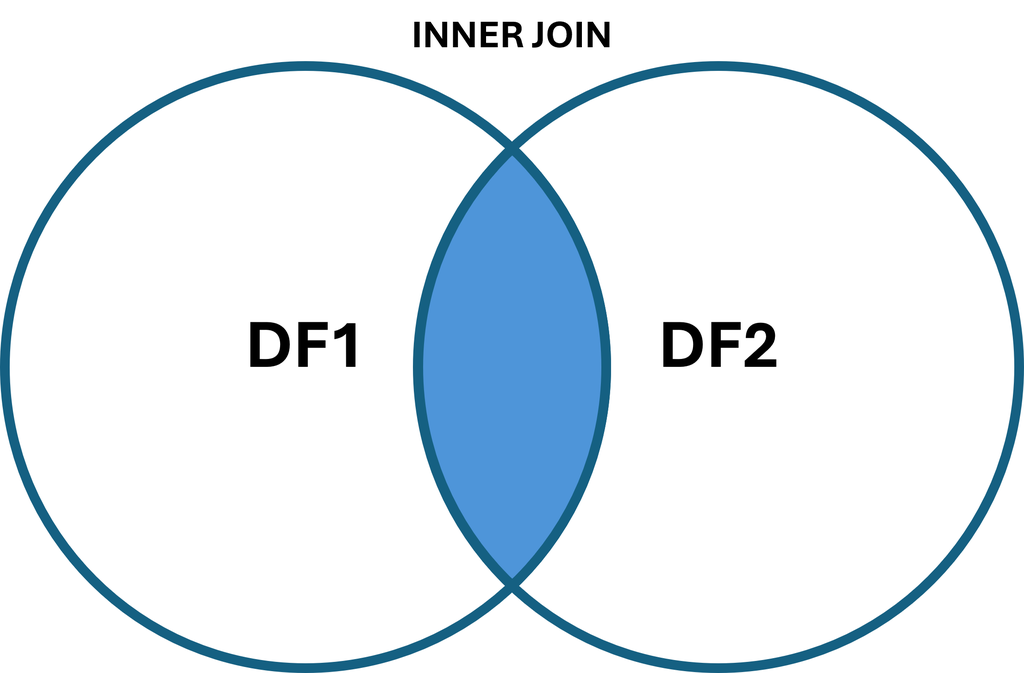

inner-join

```r
inner_join <- df1 %>%
  inner_join(df2, by = "key")
inner_join
```

| A | B | key | C | D |
| --- | --- | --- | --- | --- |
| A0 | B0 | K0 | C0 | D0 |
| A1 | B1 | K1 | C1 | D1 |
| A2 | B2 | K2 | C2 | D2 |

### Left join

The left join merges the dataframe on an index and keeps all entries from the `left` dataframe while adding the entries from the intersection with the `right` dataframe on an index column. In the result we see the entry with `key == K4` from `df2` missing as it from the `right` (`df2`) dataframe and not in the intersection with the `left` (`df1`) one. You can also see the entry with `key == K3` does not have values for columns `C` or `D` as it is not present in `df2`.

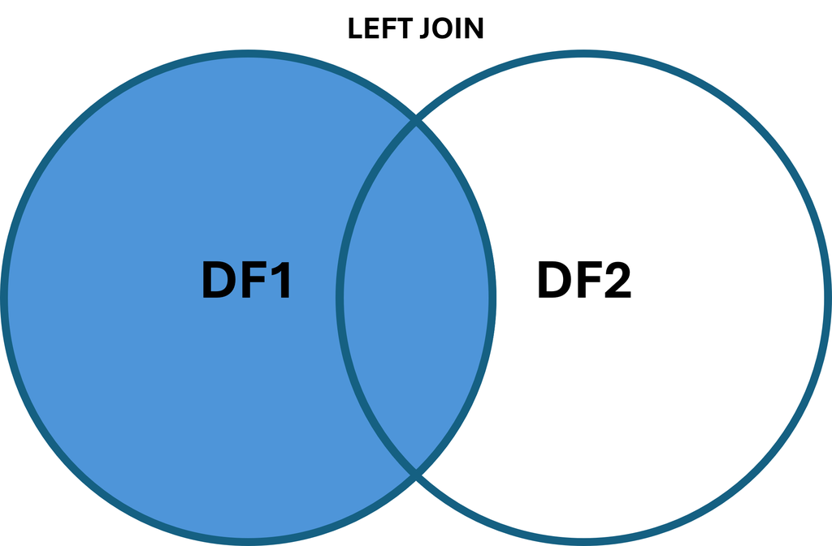

left-join

```r
left_join <- df1 %>%
  left_join(df2, by = "key")
left_join
```

| A | B | key | C | D |
| --- | --- | --- | --- | --- |
| A0 | B0 | K0 | C0 | D0 |
| A1 | B1 | K1 | C1 | D1 |
| A2 | B2 | K2 | C2 | D2 |
| A3 | B3 | K3 | NA | NA |

### Right join

The right join is just the opposite of the left join. You can always swap the order of dataframes to get from left to right join. In the result we see the entry with `key == K3` from `df1` missing as it from the `left` (`df1`) dataframe and not in the intersection with the `right` (`df2`) one.

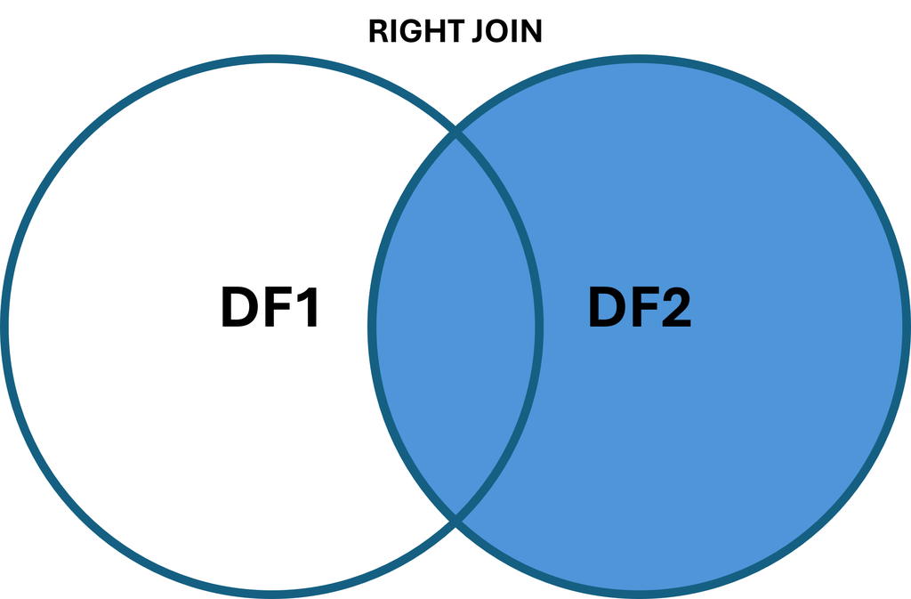

right-join

```r
right_join <- df1 %>%
  right_join(df2, by = "key")
right_join
```

| A | B | key | C | D |
| --- | --- | --- | --- | --- |
| A0 | B0 | K0 | C0 | D0 |
| A1 | B1 | K1 | C1 | D1 |
| A2 | B2 | K2 | C2 | D2 |
| NA | NA | K4 | C3 | D3 |

### Outer join

The outer join takes the union over both dataframes, so where our inner join dropped the entries with `key == K3 || key == K4`, they are now included.

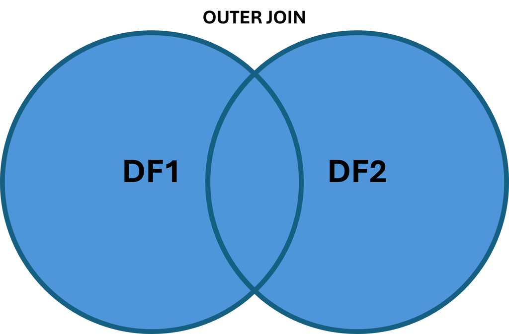

outer-join

```r
outer_join <- df1 %>%
  full_join(df2, by = "key")
outer_join
```

| A | B | key | C | D |
| --- | --- | --- | --- | --- |
| A0 | B0 | K0 | C0 | D0 |
| A1 | B1 | K1 | C1 | D1 |
| A2 | B2 | K2 | C2 | D2 |
| A3 | B3 | K3 | NA | NA |
| NA | NA | K4 | C3 | D3 |

### Concatenation

Sometimes you don’t want to combine columns from dataframes but rather just concatenate their rows with different data points. In concatenation we do not merge on a key column. If there are columns in one dataframe that do not exist in the other one, then default `NA` values will be added to rows not having this column.

```r
concatenated <- bind_rows(df1, df2)
concatenated
```

| A | B | key | C | D |
| --- | --- | --- | --- | --- |
| A0 | B0 | K0 | NA | NA |
| A1 | B1 | K1 | NA | NA |
| A2 | B2 | K2 | NA | NA |
| A3 | B3 | K3 | NA | NA |
| NA | NA | K0 | C0 | D0 |
| NA | NA | K1 | C1 | D1 |
| NA | NA | K2 | C2 | D2 |
| NA | NA | K4 | C3 | D3 |